```python
#Lets start with out imports
import seaborn as sns
import matplotlib.pyplot as pyplt
import pandas as pd
```

# La Data...

```python
# This is code from source two that will help us figure out what encoding the dataset is in :)
# import chardet

# with open("cc_institution_details.csv", 'rb') as f:
#     result = chardet.detect(f.read())

# print(result['encoding'])
```

While trying to import the data I had problems becuase of the incoding, now that we know it we can continue

```python
# dataSet = pd.read_csv("cc_institution_details.csv", encoding="ISO-8859-1") #According to source 1 I had to use this encoding to avoid an error
dataSet = pd.read_csv("cc_institution_details.csv" , encoding="Windows-1252")
dataSet
```

|  | unitid | chronname | city | state | level | control | basic | hbcu | flagship | long_x | ... | vsa_grad_after6_transfer | vsa_grad_elsewhere_after6_transfer | vsa_enroll_after6_transfer | vsa_enroll_elsewhere_after6_transfer | similar | state_sector_ct | carnegie_ct | counted_pct | nicknames | cohort_size |
| --- | --- | --- | --- | --- | --- | --- | --- | --- | --- | --- | --- | --- | --- | --- | --- | --- | --- | --- | --- | --- | --- |
| 0 | 100654 | Alabama A&M University | Normal | Alabama | 4-year | Public | Masters Colleges and Universities--larger prog... | X | NaN | -86.568502 | ... | 36.4 | 5.6 | 17.2 | 11.1 | 232937\|100724\|405997\|113607\|139533\|144005\|2285... | 13 | 386 | 99.7\|07 | NaN | 882.0 |
| 1 | 100663 | University of Alabama at Birmingham | Birmingham | Alabama | 4-year | Public | Research Universities--very high research acti... | NaN | NaN | -86.809170 | ... | NaN | NaN | NaN | NaN | 196060\|180461\|201885\|145600\|209542\|236939\|1268... | 13 | 106 | 56.0\|07 | UAB | 1376.0 |
| 2 | 100690 | Amridge University | Montgomery | Alabama | 4-year | Private not-for-profit | Baccalaureate Colleges--Arts & Sciences | NaN | NaN | -86.174010 | ... | NaN | NaN | NaN | NaN | 217925\|441511\|205124\|247825\|197647\|221856\|1353... | 16 | 252 | 100.0\|07 | NaN | 3.0 |
| 3 | 100706 | University of Alabama at Huntsville | Huntsville | Alabama | 4-year | Public | Research Universities--very high research acti... | NaN | NaN | -86.638420 | ... | 0.0 | 0.0 | 0.0 | 0.0 | 232186\|133881\|196103\|196413\|207388\|171128\|1900... | 13 | 106 | 43.1\|07 | UAH | 759.0 |
| 4 | 100724 | Alabama State University | Montgomery | Alabama | 4-year | Public | Masters Colleges and Universities--larger prog... | X | NaN | -86.295677 | ... | NaN | NaN | NaN | NaN | 100654\|232937\|242617\|243197\|144005\|241739\|2354... | 13 | 386 | 88.0\|07 | ASU | 1351.0 |
| ... | ... | ... | ... | ... | ... | ... | ... | ... | ... | ... | ... | ... | ... | ... | ... | ... | ... | ... | ... | ... | ... |
| 3793 | 461528 | Grace College of Divinity | Fayetteville | North Carolina | 4-year | Private not-for-profit | Not applicable- not in Carnegie universe | NaN | NaN | -78.961691 | ... | NaN | NaN | NaN | NaN | NaN | 43 | 81 | NaN | NaN | 12.0 |
| 3794 | 462354 | John Paul the Great Catholic University | Escondido | California | 4-year | Private not-for-profit | Not applicable- not in Carnegie universe | NaN | NaN | -117.082401 | ... | NaN | NaN | NaN | NaN | NaN | 74 | 81 | NaN | NaN | 33.0 |
| 3795 | 466921 | Chamberlain College of Nursing-Missouri | St. Louis | Missouri | 4-year | Private for-profit | Not applicable- not in Carnegie universe | NaN | NaN | -90.436221 | ... | NaN | NaN | NaN | NaN | NaN | 20 | 81 | NaN | NaN | 8.0 |
| 3796 | 474881 | Minneapolis Media Institute | Edina | Minnesota | 2-year | Private for-profit | Not applicable- not in Carnegie universe | NaN | NaN | -93.331491 | ... | NaN | NaN | NaN | NaN | NaN | 5 | 81 | NaN | NaN | 145.0 |
| 3797 | 475291 | Brown College-Brooklyn Center | Brooklyn Center | Minnesota | 4-year | Private for-profit | Not applicable- not in Carnegie universe | NaN | NaN | -93.305681 | ... | NaN | NaN | NaN | NaN | NaN | 28 | 81 | NaN | NaN | 23.0 |

3798 rows × 62 columns

```python
dataSet.describe()
```

|  | unitid | long_x | lat_y | student_count | awards_per_value | awards_per_state_value | awards_per_natl_value | exp_award_value | exp_award_state_value | exp_award_natl_value | ... | vsa_grad_elsewhere_after4_transfer | vsa_enroll_after4_transfer | vsa_enroll_elsewhere_after4_transfer | vsa_grad_after6_transfer | vsa_grad_elsewhere_after6_transfer | vsa_enroll_after6_transfer | vsa_enroll_elsewhere_after6_transfer | state_sector_ct | carnegie_ct | cohort_size |
| --- | --- | --- | --- | --- | --- | --- | --- | --- | --- | --- | --- | --- | --- | --- | --- | --- | --- | --- | --- | --- | --- |
| count | 3798.000000 | 3798.000000 | 3798.000000 | 3798.000000 | 3798.000000 | 3798.000000 | 3798.000000 | 3.798000e+03 | 3798.000000 | 3798.000000 | ... | 270.000000 | 270.000000 | 270.000000 | 270.000000 | 270.000000 | 270.000000 | 270.000000 | 3798.000000 | 3798.000000 | 3467.000000 |
| mean | 226063.790416 | -91.030391 | 38.134044 | 4476.135334 | 23.435176 | 22.845656 | 22.484044 | 6.507447e+04 | 61282.189837 | 60903.577672 | ... | 6.442222 | 12.233704 | 8.641852 | 57.960370 | 9.705926 | 3.001481 | 5.909630 | 34.284360 | 232.557662 | 658.306028 |
| std | 105065.777685 | 15.684064 | 5.040303 | 7376.868923 | 10.615140 | 6.322818 | 4.770449 | 1.074379e+05 | 33295.027077 | 29892.281333 | ... | 3.606922 | 6.220198 | 3.919950 | 16.368681 | 4.641213 | 2.158996 | 2.988662 | 28.311303 | 156.960653 | 961.782580 |
| min | 100654.000000 | -159.395966 | 19.699720 | 23.000000 | 0.500000 | 3.200000 | 16.500000 | 0.000000e+00 | 12346.000000 | 24795.000000 | ... | -13.400000 | 0.000000 | 0.000000 | 0.000000 | -9.000000 | 0.000000 | 0.000000 | 1.000000 | 1.000000 | 1.000000 |
| 25% | 155063.250000 | -97.294767 | 34.299610 | 581.250000 | 17.300000 | 19.300000 | 21.500000 | 3.231125e+04 | 35830.000000 | 37780.000000 | ... | 4.700000 | 8.325000 | 6.200000 | 51.050000 | 7.500000 | 1.525000 | 4.200000 | 14.000000 | 106.000000 | 131.000000 |
| 50% | 198075.000000 | -86.828840 | 38.988143 | 1794.500000 | 21.300000 | 22.200000 | 22.500000 | 5.057850e+04 | 54025.000000 | 38763.000000 | ... | 6.400000 | 11.800000 | 8.300000 | 59.500000 | 9.700000 | 2.700000 | 5.700000 | 25.000000 | 169.000000 | 356.000000 |
| 75% | 233745.000000 | -79.966228 | 41.633128 | 5172.000000 | 26.500000 | 24.200000 | 24.600000 | 7.693025e+04 | 79310.000000 | 101725.000000 | ... | 7.800000 | 15.075000 | 10.800000 | 68.075000 | 11.900000 | 3.900000 | 7.200000 | 48.000000 | 343.000000 | 782.500000 |
| max | 475291.000000 | -67.243306 | 71.324702 | 170144.000000 | 137.600000 | 59.900000 | 32.800000 | 5.282095e+06 | 188870.000000 | 101725.000000 | ... | 29.800000 | 64.500000 | 25.300000 | 89.300000 | 32.000000 | 17.200000 | 21.300000 | 116.000000 | 517.000000 | 16229.000000 |

8 rows × 50 columns

Using the descibe function right now is a little difficult, so what I think i'm going to do is look into my featuers and decide which ones to use (or reduce the number of featuers)

- `state`: I feel like using state we can gain insight into diffrent trends based on region
- `level` - Level of institution (4-year, 2-year)
- `control`: Control is the classification if the school is Public, private non-profit, or private for-profit
- `hbcu`: Historically Black College
- `flagship`: Basically if the school is a "Flagship" insitituation (ex. UNC, University of Michigan)
- `student_count` - Total number of undergraduates in 2010
- `exp_award_value`: The amount of educational sepnding per award (degree/certificate)
- `retain_value`: Share of freshmen retained for a second year
- `pell_value`: percentage of undergraduates receiving a Pell Grant
- `ft_fac_value`: Percentage of employees devoted to instruction, research or public service who are full-time and do not work for an associated medical school
- `counted_pct`: share entering undergraduate class who were first-time, full-time, degree-seeking students, meaning that they generally would be part of a tracked cohort of potential graduates. The entering class of 2007 is displayed for 4-year institutions; 2010 for 2-year institutions.
- `aid_value` - The average amount of student aid going to undergraduate recipients

**VSA Schools**

The **Voluntary System of Accountability (VSA)** are a statistic where "numbers are based on student cohort data from the National Student Clearinghouse for first-time, full-time students and full-time transfer students. About half of four-year public institutions we examined have reported these data. Because it’s linked to a particular student instead of an institution, these figures can show outcomes for students who enter and leave a particular college in a way traditional graduation rates cannot."

**The Dependent Variable**

- `grad_100_value`: percentage of first-time, full-time, degree-seeking undergraduates who complete a degree or certificate program within 100 percent of expected time (bachelor's-seeking group at 4-year institutions)
- `grad_150_value`: percentage of first-time, full-time, degree-seeking undergraduates who complete a degree or certificate program within 150 percent of expected time (bachelor's-seeking group at 4-year institutions)

Based on my source grad_150_value includes grad_100_value. I want to say grad_150 is better for asking the question of "are people graduating?" while grad_100 is asking "Are people graduating within the traditional time-frame?"

```python
includeFeatuers = ['chronname', 'state', 'level', 'control', 'hbcu', 'flagship', 'student_count', 'exp_award_value', 'retain_value', 'pell_value', 'ft_fac_value', 'aid_value', 'counted_pct', 'grad_100_value', 'grad_150_value']
dataSet2 = dataSet[includeFeatuers]
dataSet2
```

|  | chronname | state | level | control | hbcu | flagship | student_count | exp_award_value | retain_value | pell_value | ft_fac_value | aid_value | counted_pct | grad_100_value | grad_150_value |
| --- | --- | --- | --- | --- | --- | --- | --- | --- | --- | --- | --- | --- | --- | --- | --- |
| 0 | Alabama A&M University | Alabama | 4-year | Public | X | NaN | 4051 | 105331 | 63.1 | 71.2 | 82.8 | 7142.0 | 99.7\|07 | 10.0 | 29.1 |
| 1 | University of Alabama at Birmingham | Alabama | 4-year | Public | NaN | NaN | 11502 | 136546 | 80.2 | 35.1 | 92.4 | 6088.0 | 56.0\|07 | 29.4 | 53.5 |
| 2 | Amridge University | Alabama | 4-year | Private not-for-profit | NaN | NaN | 322 | 58414 | 37.5 | 68.4 | 67.2 | 2540.0 | 100.0\|07 | 0.0 | 66.7 |
| 3 | University of Alabama at Huntsville | Alabama | 4-year | Public | NaN | NaN | 5696 | 64418 | 81.0 | 32.8 | 65.5 | 6647.0 | 43.1\|07 | 16.5 | 48.4 |
| 4 | Alabama State University | Alabama | 4-year | Public | X | NaN | 5356 | 132407 | 62.2 | 82.7 | 67.0 | 7256.0 | 88.0\|07 | 8.8 | 25.2 |
| ... | ... | ... | ... | ... | ... | ... | ... | ... | ... | ... | ... | ... | ... | ... | ... |
| 3793 | Grace College of Divinity | North Carolina | 4-year | Private not-for-profit | NaN | NaN | 110 | 24047 | 33.3 | 26.3 | 10.7 | 4860.0 | NaN | 0.0 | 0.0 |
| 3794 | John Paul the Great Catholic University | California | 4-year | Private not-for-profit | NaN | NaN | 140 | 105965 | 74.4 | 28.3 | 44.4 | 9395.0 | NaN | 51.5 | 51.5 |
| 3795 | Chamberlain College of Nursing-Missouri | Missouri | 4-year | Private for-profit | NaN | NaN | 488 | 52936 | 77.8 | 53.1 | 29.6 | 3291.0 | NaN | 37.5 | 37.5 |
| 3796 | Minneapolis Media Institute | Minnesota | 2-year | Private for-profit | NaN | NaN | 147 | 74857 | 78.9 | 40.8 | 42.3 | 3434.0 | NaN | 42.1 | 55.9 |
| 3797 | Brown College-Brooklyn Center | Minnesota | 4-year | Private for-profit | NaN | NaN | 144 | 48074 | NaN | 86.5 | 6.9 | 5379.0 | NaN | 34.8 | 47.8 |

3798 rows × 15 columns

```python
dataSet2.describe()
```

|  | student_count | exp_award_value | retain_value | pell_value | ft_fac_value | aid_value | grad_100_value | grad_150_value |
| --- | --- | --- | --- | --- | --- | --- | --- | --- |
| count | 3798.000000 | 3.798000e+03 | 3535.000000 | 3797.000000 | 3785.000000 | 3797.000000 | 3467.000000 | 3467.000000 |
| mean | 4476.135334 | 6.507447e+04 | 66.231853 | 47.572057 | 45.107477 | 7960.445878 | 28.364465 | 42.407586 |
| std | 7376.868923 | 1.074379e+05 | 17.033907 | 20.065216 | 24.726902 | 6419.658196 | 23.312730 | 23.460824 |
| min | 23.000000 | 0.000000e+00 | 0.000000 | 0.000000 | 0.000000 | 294.000000 | 0.000000 | 0.000000 |
| 25% | 581.250000 | 3.231125e+04 | 56.100000 | 32.400000 | 25.700000 | 4018.000000 | 9.000000 | 22.700000 |
| 50% | 1794.500000 | 5.057850e+04 | 66.900000 | 44.700000 | 41.500000 | 5207.000000 | 22.500000 | 41.100000 |
| 75% | 5172.000000 | 7.693025e+04 | 78.100000 | 62.500000 | 63.000000 | 9343.000000 | 43.650000 | 60.250000 |
| max | 170144.000000 | 5.282095e+06 | 100.000000 | 100.000000 | 100.000000 | 41580.000000 | 100.000000 | 100.000000 |

ok...well the descirbe function is still not where we want it to be. This is becuase we have some featuers that need to be formatted. This is starting to feel like preprocessing rather than data insight, so lets go ahead and start!

# Pre-Processing

## The Featuers - Null Values, Data types, Buckets, One-Hot Encoding

```python
dataSet2.dtypes
```

```
chronname           object
state               object
level               object
control             object
hbcu                object
flagship            object
student_count        int64
exp_award_value      int64
retain_value       float64
pell_value         float64
ft_fac_value       float64
aid_value          float64
counted_pct         object
grad_100_value     float64
grad_150_value     float64
dtype: object
```

```python
for col in dataSet2:
    print(f'{col}:\n{dataSet2[col].value_counts()}')
```

```
chronname:
Metro Business College             3
ITT Technical Institute-Madison    3
Anamarc College                    2
Alabama A&M University             1
Sisseton-Wahpeton College          1
                                  ..
Gogebic Community College          1
Grace Bible College                1
Cornerstone University             1
Grand Rapids Community College     1
Brown College-Brooklyn Center      1
Name: chronname, Length: 3793, dtype: int64
state:
California              350
New York                241
Pennsylvania            217
Texas                   207
Ohio                    185
Florida                 176
Illinois                141
North Carolina          135
Georgia                 106
Virginia                104
Missouri                103
Minnesota               101
Massachusetts           100
Tennessee                94
Michigan                 94
Washington               73
Wisconsin                71
Colorado                 70
Alabama                  69
Indiana                  67
Kentucky                 67
South Carolina           66
Arizona                  63
Kansas                   62
Iowa                     61
Louisiana                56
```

[output cut: 143 more lines]

```
69.7      1
Name: grad_100_value, Length: 806, dtype: int64
grad_150_value:
0.0     71
50.0    23
25.0    21
33.3    20
42.9    19
        ..
88.4     1
55.1     1
35.3     1
93.0     1
82.7     1
Name: grad_150_value, Length: 862, dtype: int64
```

Okay what did we learn...

- For out HBCU & Flagship Catergorical Variables, they use null to represent that they do not classify as that so were gonna have to go in and fix that.
- There are a couple of values continuous variables like `student_count` that have buckets. This is a little concerning, but we will try not to worry about it since it’s possible.
- `exp_award_value`, `ft_fac_value`, and our dependent variables `grad_100_value` & `grad_150_value` have a bucket 0. This is concerning because it could represent null or it could represent 0. For the 0 values they had 121, 27, 219, 71 respectively. For all four I want to say that it’s unlikely that the value would be 0, but before we make any assumptions let's see what our isnull functions returns.

```python
dataSet2.isnull().sum()
```

```
chronname             0
state                 0
level                 0
control               0
hbcu               3704
flagship           3748
student_count         0
exp_award_value       0
retain_value        263
pell_value            1
ft_fac_value         13
aid_value             1
counted_pct         426
grad_100_value      331
grad_150_value      331
dtype: int64
```

`hbcu` & `flagship`

- These null values arnt actually null. We will repalce the null values with 0 to represent that they are not classified as hbcu or flagship

`exp_award_value`

- For this value we had values that had 0. im not sure if I should count them as null, so I will leave them as is

`retain_value`

- 263 Nulls that we will need to deal with

`pell_value`

- Just one null Value

`ft_fac_value`

- Turns out we have nulls and 0, so I think the 0's are actual 0's and we will have to handle the nulls

`aid_value`

- Just one null value

`counted_pct`

- 426 null values

`grad_100_value` & `grad_150_value`

- These have null values, so I guess the 0s mean that no one that is part of the counted cohort of students being tracked graduated. Also, this could mean that they didn’t track anyone, but I’m not sure why they wouldn’t do null in that case.

For `counted_pct` I will just drop the column insted of losing those enteries.

```python
dataSet2.drop(columns=["counted_pct"], inplace= True)
```

## HBCU & Flagship Nulls and One-hot Encoding

```python
#Note we need to make sure we run this line only once.
dataSet2.loc[dataSet2["hbcu"] == "X", "hbcu"] = 1
dataSet2.loc[dataSet2["flagship"] == "X", "flagship"] = 1
```

```python
dataSet2.fillna({"hbcu" : 0, "flagship" : 0}, inplace=True)
```

```python
print(f"hbcu Nulls: {dataSet2['hbcu'].isna().sum()} flagship Nulls: {dataSet2['flagship'].isna().sum()}")
dataSet2[['hbcu', 'flagship']]
```

```
hbcu Nulls: 0 flagship Nulls: 0
```

|  | hbcu | flagship |
| --- | --- | --- |
| 0 | 1 | 0 |
| 1 | 0 | 0 |
| 2 | 0 | 0 |
| 3 | 0 | 0 |
| 4 | 1 | 0 |
| ... | ... | ... |
| 3793 | 0 | 0 |
| 3794 | 0 | 0 |
| 3795 | 0 | 0 |
| 3796 | 0 | 0 |
| 3797 | 0 | 0 |

3798 rows × 2 columns

```python
dataSet2.dropna(inplace=True)
dataSet2.isnull().sum()
```

```
chronname          0
state              0
level              0
control            0
hbcu               0
flagship           0
student_count      0
exp_award_value    0
retain_value       0
pell_value         0
ft_fac_value       0
aid_value          0
grad_100_value     0
grad_150_value     0
dtype: int64
```

## Level & State One-Hot Encoding

For `state` I think i'm going to try to seperate each entery into regions (North, South, etc) so that way we have less dummy variables and are able to get a better understanding of the data.

`level`

- Level has to do with four year or two year, but it's binary so I could just change the column to is2year and then make it 0 and 1 in one columns

`control`

- We will have to use the get dummies function here becuase we are dealing with more than one choice

```python
#First step is to group the states into regions
regions = {
    'northeast': ['Connecticut', 'Maine', 'Massachusetts', 'New Hampshire', 'Rhode Island', 'Vermont', 'New Jersey', 'New York', 'Pennsylvania'],
    'midwest': ['Illinois', 'Indiana', 'Michigan', 'Ohio', 'Wisconsin', 'Iowa', 'Kansas', 'Minnesota', 'Missouri', 'Nebraska', 'North Dakota', 'South Dakota'],
    'south': ['Delaware', 'Florida', 'Georgia', 'Maryland', 'North Carolina', 'South Carolina', 'Virginia', 'District of Columbia', 'West Virginia', 'Alabama', 'Kentucky', 'Mississippi', 'Tennessee', 'Arkansas', 'Louisiana', 'Oklahoma', 'Texas'],
    'west': ['Arizona', 'Colorado', 'Idaho', 'Montana', 'Nevada', 'New Mexico', 'Utah', 'Wyoming', 'Alaska', 'California', 'Hawaii', 'Oregon', 'Washington']
}

#Now we will create a function that returns the region that state is in based on the input
def find_region(state):
    for region, states in regions.items():
        if state in states:
            return region
    return 0
```

```python
#Im just going to default the value to 0 to save us some work in the future
dataSet2["northeast"] = 0
dataSet2["midwest"] = 0
dataSet2["south"] = 0
dataSet2["west"] = 0
dataSet2
```

|  | chronname | state | level | control | hbcu | flagship | student_count | exp_award_value | retain_value | pell_value | ft_fac_value | aid_value | grad_100_value | grad_150_value | northeast | midwest | south | west |
| --- | --- | --- | --- | --- | --- | --- | --- | --- | --- | --- | --- | --- | --- | --- | --- | --- | --- | --- |
| 0 | Alabama A&M University | Alabama | 4-year | Public | 1 | 0 | 4051 | 105331 | 63.1 | 71.2 | 82.8 | 7142.0 | 10.0 | 29.1 | 0 | 0 | 0 | 0 |
| 1 | University of Alabama at Birmingham | Alabama | 4-year | Public | 0 | 0 | 11502 | 136546 | 80.2 | 35.1 | 92.4 | 6088.0 | 29.4 | 53.5 | 0 | 0 | 0 | 0 |
| 2 | Amridge University | Alabama | 4-year | Private not-for-profit | 0 | 0 | 322 | 58414 | 37.5 | 68.4 | 67.2 | 2540.0 | 0.0 | 66.7 | 0 | 0 | 0 | 0 |
| 3 | University of Alabama at Huntsville | Alabama | 4-year | Public | 0 | 0 | 5696 | 64418 | 81.0 | 32.8 | 65.5 | 6647.0 | 16.5 | 48.4 | 0 | 0 | 0 | 0 |
| 4 | Alabama State University | Alabama | 4-year | Public | 1 | 0 | 5356 | 132407 | 62.2 | 82.7 | 67.0 | 7256.0 | 8.8 | 25.2 | 0 | 0 | 0 | 0 |
| ... | ... | ... | ... | ... | ... | ... | ... | ... | ... | ... | ... | ... | ... | ... | ... | ... | ... | ... |
| 3792 | Keweenaw Bay Ojibwa Community College | Michigan | 2-year | Public | 0 | 0 | 106 | 126733 | 33.3 | 74.4 | 28.6 | 4710.0 | 0.0 | 0.0 | 0 | 0 | 0 | 0 |
| 3793 | Grace College of Divinity | North Carolina | 4-year | Private not-for-profit | 0 | 0 | 110 | 24047 | 33.3 | 26.3 | 10.7 | 4860.0 | 0.0 | 0.0 | 0 | 0 | 0 | 0 |
| 3794 | John Paul the Great Catholic University | California | 4-year | Private not-for-profit | 0 | 0 | 140 | 105965 | 74.4 | 28.3 | 44.4 | 9395.0 | 51.5 | 51.5 | 0 | 0 | 0 | 0 |
| 3795 | Chamberlain College of Nursing-Missouri | Missouri | 4-year | Private for-profit | 0 | 0 | 488 | 52936 | 77.8 | 53.1 | 29.6 | 3291.0 | 37.5 | 37.5 | 0 | 0 | 0 | 0 |
| 3796 | Minneapolis Media Institute | Minnesota | 2-year | Private for-profit | 0 | 0 | 147 | 74857 | 78.9 | 40.8 | 42.3 | 3434.0 | 42.1 | 55.9 | 0 | 0 | 0 | 0 |

3371 rows × 18 columns

```python
#Now thanks to the function we created, getting the values is as easy as:
for column, row in dataSet2.iterrows():
    dataSet2.loc[row.name, find_region(row["state"])] = 1
```

```python
#Now we need to get rid of one of these regions to prevent Multi-collinearity
dataSet2.drop(columns="midwest", inplace=True)
```

```python
dataSet2.columns
```

```
Index(['chronname', 'state', 'level', 'control', 'hbcu', 'flagship',
       'student_count', 'exp_award_value', 'retain_value', 'pell_value',
       'ft_fac_value', 'aid_value', 'grad_100_value', 'grad_150_value',
       'northeast', 'south', 'west'],
      dtype='object')
```

Now we do `level`

```python
#Careful with the following code it will make the entire column null if ran more than once
dataSet2["level"] = dataSet2["level"].replace({"4-year" : 1, "2-year" : 0})
```

```python
dataSet2.rename(columns={'level' : 'is_four_year'}, inplace=True)
```

lastly, we will take care of the control column and then check to make sure all of our columns are numerical

```python
dataSet2 = pd.get_dummies(dataSet2, columns=["control"], drop_first= True)
```

```python
print(dataSet2.dtypes)
```

```
chronname                          object
state                              object
is_four_year                        int64
hbcu                                int64
flagship                            int64
student_count                       int64
exp_award_value                     int64
retain_value                      float64
pell_value                        float64
ft_fac_value                      float64
aid_value                         float64
grad_100_value                    float64
grad_150_value                    float64
northeast                           int64
south                               int64
west                                int64
control_Private not-for-profit      uint8
control_Public                      uint8
dtype: object
```

## Formatting Values

I noticed for our regression we can make it easier to interpret if we format a couple of values:

`student_count`

- We are going to change this to students in 100 - basically per 100 students

`exp_award_value`

- We are going to change this to hundred dollars

`aid_value`

- we are going to change this to hundred dollars

```python
dataSet2["student_count"] = dataSet2["student_count"]/100
dataSet2["exp_award_value"] = dataSet2["exp_award_value"]/100
dataSet2["aid_value"] = dataSet2["aid_value"]/100
```

```python
dataSet2[["student_count", "exp_award_value", "aid_value"]]
```

|  | student_count | exp_award_value | aid_value |
| --- | --- | --- | --- |
| 0 | 40.51 | 1053.31 | 71.42 |
| 1 | 115.02 | 1365.46 | 60.88 |
| 2 | 3.22 | 584.14 | 25.40 |
| 3 | 56.96 | 644.18 | 66.47 |
| 4 | 53.56 | 1324.07 | 72.56 |
| ... | ... | ... | ... |
| 3792 | 1.06 | 1267.33 | 47.10 |
| 3793 | 1.10 | 240.47 | 48.60 |
| 3794 | 1.40 | 1059.65 | 93.95 |
| 3795 | 4.88 | 529.36 | 32.91 |
| 3796 | 1.47 | 748.57 | 34.34 |

3371 rows × 3 columns

```python
dataSet2.describe()
```

|  | is_four_year | hbcu | flagship | student_count | exp_award_value | retain_value | pell_value | ft_fac_value | aid_value | grad_100_value | grad_150_value | northeast | south | west | control_Private not-for-profit | control_Public |
| --- | --- | --- | --- | --- | --- | --- | --- | --- | --- | --- | --- | --- | --- | --- | --- | --- |
| count | 3371.000000 | 3371.000000 | 3371.000000 | 3371.000000 | 3371.000000 | 3371.000000 | 3371.000000 | 3371.000000 | 3371.000000 | 3371.000000 | 3371.000000 | 3371.000000 | 3371.000000 | 3371.000000 | 3371.000000 | 3371.000000 |
| mean | 0.571937 | 0.027292 | 0.014832 | 47.833595 | 678.115206 | 66.699763 | 45.763364 | 47.042539 | 83.551735 | 28.619371 | 42.901187 | 0.207357 | 0.346781 | 0.197271 | 0.350044 | 0.443192 |
| std | 0.494871 | 0.162956 | 0.120900 | 75.027313 | 1131.033598 | 15.995472 | 19.458833 | 24.293820 | 66.611135 | 23.208964 | 23.172944 | 0.405474 | 0.476016 | 0.397998 | 0.477054 | 0.496836 |
| min | 0.000000 | 0.000000 | 0.000000 | 0.230000 | 0.000000 | 0.000000 | 0.000000 | 0.000000 | 2.940000 | 0.000000 | 0.000000 | 0.000000 | 0.000000 | 0.000000 | 0.000000 | 0.000000 |
| 25% | 0.000000 | 0.000000 | 0.000000 | 7.390000 | 335.255000 | 56.400000 | 31.600000 | 27.800000 | 40.745000 | 9.300000 | 23.600000 | 0.000000 | 0.000000 | 0.000000 | 0.000000 | 0.000000 |
| 50% | 1.000000 | 0.000000 | 0.000000 | 20.440000 | 527.920000 | 67.100000 | 43.100000 | 44.000000 | 54.720000 | 23.100000 | 41.700000 | 0.000000 | 0.000000 | 0.000000 | 0.000000 | 0.000000 |
| 75% | 1.000000 | 0.000000 | 0.000000 | 56.555000 | 800.300000 | 78.100000 | 58.450000 | 64.400000 | 105.330000 | 43.900000 | 60.500000 | 0.000000 | 1.000000 | 0.000000 | 1.000000 | 1.000000 |
| max | 1.000000 | 1.000000 | 1.000000 | 1701.440000 | 52820.950000 | 100.000000 | 100.000000 | 100.000000 | 415.800000 | 100.000000 | 100.000000 | 1.000000 | 1.000000 | 1.000000 | 1.000000 | 1.000000 |

# Visualization

## Heatmap

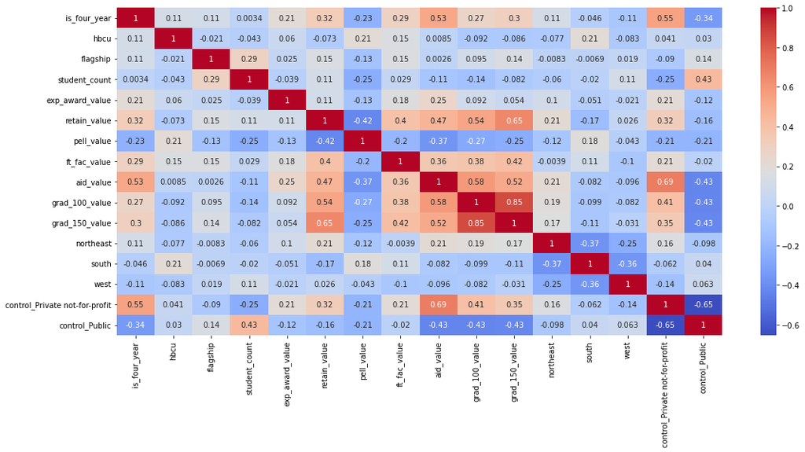

```python
corr = dataSet2.corr()
pyplt.figure(figsize = (18,8))
sns.heatmap(corr, annot = True, cmap='coolwarm')
```

Heatmaps show use the relationship between variables, so it's important to know what each variable stands for and why it would have a certian relationship with another variable.

`grad_150_value`

Looking at the heat map we notice how correlated **grad_100_value** is to **grad_150_value**. This makes sense becuase **grad_100_value** is a mathmatical artifact to **grad_150_value** so the correlation is not causation, rather it's becuase grad_150_value includes the values in grad_100_value.

`aid_value & Private not-for-profit`

This was an intresting correlation. Our heap map shows us that there is a positive correlation between private not for profit colleges and the % of aid that undergraduate student recieve relative to student at profit and public schools.

`Retain_value & grad_150_value`

This is a relationship where I feel like it might be a mathmatical artifact. This is becuase if more students are retained then the grad_150_value will be higher. This is important to note

# Experiment 1: Just a plain old regression

For my first expirment I will use an OLS regression from stat models becuase I like how it prints out the results. We will start by predicting grad_150_value and figuring that out first

```python
import statsmodels.api as sm
from sklearn.preprocessing import scale
```

First we drop featuers and set up our variables

```python
X = dataSet2.drop(columns=["chronname", "state", "grad_100_value", "grad_150_value"])
y = dataSet2["grad_150_value"]
# X2 = sm.add_constant(X) #We add a constant for stats models,
```

For the scikit model we will split the data aswell, but notice that we do not add a constant, this is something we do only with `statsmodels`

```python
#Scaling the X and y
from sklearn.model_selection import train_test_split
X_train, X_test, y_train, y_test = train_test_split(X, y, test_size = 0.3, random_state = 1)
```

## **Standardized Data** - Using Scikit

To begin we will import our tools and begin the data pipeline (Standardize and scale data)

```python
from sklearn.pipeline import Pipeline
from sklearn.linear_model import LinearRegression
from sklearn.metrics import mean_absolute_error, r2_score
from sklearn.preprocessing import StandardScaler, PolynomialFeatures

lr_Pipleline = Pipeline([
        ('StandardScaler', StandardScaler()),
        ('LinearRegression', LinearRegression())
    ]).fit(X_train, y_train)

lr_pred = lr_Pipleline.predict(X_test)
lrMAE = mean_absolute_error(y_test, lr_pred)

print(f"r2: {r2_score(y_test, lr_pred)}")
print(f"Mean Absolute Error: {lrMAE}")
```

```
r2: 0.6224724711187659
Mean Absolute Error: 9.9057606244779
```

## **No Standardization**

```python
X2 = sm.add_constant(X_train) #adding a constant, very important step do not forget

nonscaled_model = sm.OLS(y_train, X2)

nonscaled_results = nonscaled_model.fit()

print(nonscaled_results.summary())
```

```
                            OLS Regression Results
==============================================================================
Dep. Variable:         grad_150_value   R-squared:                       0.634
Model:                            OLS   Adj. R-squared:                  0.632
Method:                 Least Squares   F-statistic:                     289.6
Date:                Sun, 24 Mar 2024   Prob (F-statistic):               0.00
Time:                        14:41:28   Log-Likelihood:                -9584.7
No. Observations:                2359   AIC:                         1.920e+04
Df Residuals:                    2344   BIC:                         1.929e+04
Df Model:                          14
Covariance Type:            nonrobust
==================================================================================================
                                     coef    std err          t      P>|t|      [0.025      0.975]
--------------------------------------------------------------------------------------------------
const                              8.2900      2.317      3.578      0.000       3.747      12.833
is_four_year                      -2.0432      0.753     -2.715      0.007      -3.519      -0.567
hbcu                              -2.6065      2.000     -1.304      0.193      -6.528       1.315
flagship                          15.2896      2.499      6.117      0.000      10.388      20.191
student_count                     -0.0084      0.004     -1.964      0.050      -0.017   -1.32e-05
exp_award_value                   -0.0018      0.000     -7.577      0.000      -0.002      -0.001
retain_value                       0.6554      0.023     27.999      0.000       0.609       0.701
pell_value                        -0.1286      0.021     -6.243      0.000      -0.169      -0.088
ft_fac_value                       0.2107      0.014     14.984      0.000       0.183       0.238
aid_value                          0.0686      0.007      9.871      0.000       0.055       0.082
northeast                          0.1564      0.882      0.177      0.859      -1.574       1.887
south                             -1.1098      0.785     -1.414      0.158      -2.649       0.430
west                              -1.2490      0.897     -1.392      0.164      -3.009       0.511
control_Private not-for-profit   -13.6999      1.095    -12.511      0.000     -15.847     -11.553
control_Public                   -23.3920      0.965    -24.240      0.000     -25.284     -21.500
==============================================================================
Omnibus:                      172.760   Durbin-Watson:                   1.980
Prob(Omnibus):                  0.000   Jarque-Bera (JB):              884.729
Skew:                          -0.065   Prob(JB):                    7.65e-193
Kurtosis:                       5.997   Cond. No.                     1.29e+04
==============================================================================

Notes:
[1] Standard Errors assume that the covariance matrix of the errors is correctly specified.
[2] The condition number is large, 1.29e+04. This might indicate that there are
strong multicollinearity or other numerical problems.
```

Lets test the statsmodels predictions too

```python
#This area to test the non-scaled models predictive value
X3 = sm.add_constant(X_test)

sm_predictions = nonscaled_results.predict(X3)

print(f"r2: {r2_score(y_test, sm_predictions)}")
print(f"MAE: {mean_absolute_error(y_test, sm_predictions)}")

print(f"Diffrence in r2: {r2_score(y_test, sm_predictions) - r2_score(y_test, lr_pred)}\nDiffrence in MAE: {mean_absolute_error(y_test, sm_predictions) - mean_absolute_error(y_test, lr_pred)}")
```

```
r2: 0.6224724711187826
MAE: 9.905760624477592
Diffrence in r2: 1.6653345369377348e-14
Diffrence in MAE: -3.0730973321624333e-13
```

# Expirement 2 - Polynomial Variables (Scikit)

For the polynomial features we will first loop and try to find the best number of polynomial featuers since if we add to many it will cause overfitting. Let's see what happen

```python
def findBestNumOfPoly(numOfPoly):
    lr_Pipleline = Pipeline([
        ('StandardScaler', StandardScaler()),
        ('PolynomialFeatures', PolynomialFeatures(numOfPoly)),
        ('LinearRegression', LinearRegression())
    ]).fit(X_train, y_train)

    lr_pred = lr_Pipleline.predict(X_test)

    print(f"\nNumber of polynomials:{numOfPoly}")
    print(f"r2: {r2_score(y_test, lr_pred)}")
    print(f"Mean Absolute Error: {mean_absolute_error(y_test, lr_pred)}")
```

```python
for num in range(1, 6, 1):
    findBestNumOfPoly(num)
```

```
Number of polynomials:1
r2: 0.6224724711187659
Mean Absolute Error: 9.905760624477896

Number of polynomials:2
r2: 0.6757713954137903
Mean Absolute Error: 8.721436318861167

Number of polynomials:3
r2: -318294103540707.56
Mean Absolute Error: 19446234.829054564

Number of polynomials:4
r2: -153835036440058.7
Mean Absolute Error: 29218293.650210895

Number of polynomials:5
r2: -21522637.84059453
Mean Absolute Error: 5030.56571756194
```

```python
8.721436318861167 - lrMAE
```

```
-1.184324305616732
```

# Expirement 3 - SGDRegressor

```python
from sklearn.linear_model import SGDRegressor

sgd_Pipleline = Pipeline([
        ('StandardScaler', StandardScaler()),
        ('SGDRegressor', SGDRegressor(random_state=1))
    ]).fit(X_train, y_train)

sgd_projections = sgd_Pipleline.predict(X_test)
sgdr2 = r2_score(y_test, sgd_projections)
sgdMAE = mean_absolute_error(y_test, sgd_projections)

print(f"r2: {sgdr2}")
print(f"MAE: {sgdMAE}")

print(f"Diffrence in MAE: {sgdMAE- lrMAE}")
```

```
r2: 0.6226788689200602
MAE: 9.828079953533535
Diffrence in MAE: -0.07768067094436404
```